# **악세서리 bestseller 분류**

김지수

2019.9.31

## **주제**

악세사리가 bestseller인지 확인합니다.

## **데이터 소개**

악세사리 중 품목유형과 품목의 사용된 보석 또는 물자를 확인하여 물품이 bestseller 인지 아닌지 예측합니다 라벨 변수는 best_seller입니다.

```r
setwd('C:\\data')
best <- read.csv("c:\\data\\bestseller.csv")
str(best)
```

```
## 'data.frame':    337 obs. of  44 variables:
##  $ ID         : num  0 1 2 3 4 5 6 7 8 9 ...
##  $ best_seller: num  1 1 1 1 1 1 1 1 1 1 ...
##  $ price      : Factor w/ 79 levels "SR1,100","SR1,200",..: 48 57 41 41 3 70 70 8 41 41 ...
##  $ image      : Factor w/ 335 levels "['https://cdn.tous.com/media/catalog/product/cache/image/512x512/9df78eab33525d08d6e5fb8d27136e95/0/1/015901540.jpg']",..: 5 38 11 40 44 21 20 2 45 46 ...
##  $ bracelet   : num  0 0 0 0 0 0 0 0 0 0 ...
##  $ ring       : num  1 1 1 0 1 1 1 1 0 0 ...
##  $ necklace   : num  0 0 0 0 0 0 0 0 0 0 ...
##  $ earring    : num  1 1 1 0 1 1 1 1 0 0 ...
##  $ choker     : num  0 0 0 0 0 0 0 0 0 0 ...
##  $ pendant    : num  0 0 0 1 0 0 0 0 1 1 ...
##  $ mesh       : num  0 0 0 0 0 0 0 0 0 0 ...
##  $ gold       : num  0 0 0 0 1 1 1 1 0 0 ...
##  $ silver     : num  1 1 1 1 0 0 0 0 1 1 ...
##  $ white      : num  0 0 0 0 0 0 0 0 0 0 ...
```

[output cut: 30 more lines]

best의 image 컬럼은 이번 분석에서 사용하지 않으므로 제외하고 진행하겠습니다.

```r
best<-best[c(-4,-22,-23,-25,-26,-27,-29,-30)]
str(best)
```

```
## 'data.frame':    337 obs. of  36 variables:
##  $ ID         : num  0 1 2 3 4 5 6 7 8 9 ...
##  $ best_seller: num  1 1 1 1 1 1 1 1 1 1 ...
##  $ price      : Factor w/ 79 levels "SR1,100","SR1,200",..: 48 57 41 41 3 70 70 8 41 41 ...
##  $ bracelet   : num  0 0 0 0 0 0 0 0 0 0 ...
##  $ ring       : num  1 1 1 0 1 1 1 1 0 0 ...
##  $ necklace   : num  0 0 0 0 0 0 0 0 0 0 ...
##  $ earring    : num  1 1 1 0 1 1 1 1 0 0 ...
##  $ choker     : num  0 0 0 0 0 0 0 0 0 0 ...
##  $ pendant    : num  0 0 0 1 0 0 0 0 1 1 ...
##  $ mesh       : num  0 0 0 0 0 0 0 0 0 0 ...
##  $ gold       : num  0 0 0 0 1 1 1 1 0 0 ...
##  $ silver     : num  1 1 1 1 0 0 0 0 1 1 ...
##  $ white      : num  0 0 0 0 0 0 0 0 0 0 ...
##  $ titanium   : num  0 0 0 0 0 0 0 0 0 0 ...
```

[output cut: 22 more lines]

데이터 컬럼의 자료구조를 모두 factor로 변환시켜줍니다

```r
for(i in 1:ncol(best)){
  best[,i] <- factor(best[,i])  }
str(best)
```

```
## 'data.frame':    337 obs. of  36 variables:
##  $ ID         : Factor w/ 337 levels "0","1","2","3",..: 1 2 3 4 5 6 7 8 9 10 ...
##  $ best_seller: Factor w/ 2 levels "0","1": 2 2 2 2 2 2 2 2 2 2 ...
##  $ price      : Factor w/ 79 levels "SR1,100","SR1,200",..: 48 57 41 41 3 70 70 8 41 41 ...
##  $ bracelet   : Factor w/ 2 levels "0","1": 1 1 1 1 1 1 1 1 1 1 ...
##  $ ring       : Factor w/ 2 levels "0","1": 2 2 2 1 2 2 2 2 1 1 ...
##  $ necklace   : Factor w/ 2 levels "0","1": 1 1 1 1 1 1 1 1 1 1 ...
##  $ earring    : Factor w/ 2 levels "0","1": 2 2 2 1 2 2 2 2 1 1 ...
##  $ choker     : Factor w/ 2 levels "0","1": 1 1 1 1 1 1 1 1 1 1 ...
##  $ pendant    : Factor w/ 2 levels "0","1": 1 1 1 2 1 1 1 1 2 2 ...
##  $ mesh       : Factor w/ 2 levels "0","1": 1 1 1 1 1 1 1 1 1 1 ...
##  $ gold       : Factor w/ 2 levels "0","1": 1 1 1 1 2 2 2 2 1 1 ...
##  $ silver     : Factor w/ 2 levels "0","1": 2 2 2 2 1 1 1 1 2 2 ...
##  $ white      : Factor w/ 2 levels "0","1": 1 1 1 1 1 1 1 1 1 1 ...
##  $ titanium   : Factor w/ 2 levels "0","1": 1 1 1 1 1 1 1 1 1 1 ...
```

[output cut: 22 more lines]

## **데이터 탐색**

bestseller와 일반 판매 물건의 비율입니다.

```r
round(prop.table(table(best$best_seller)),3)
```

```
##
##     0     1
## 0.855 0.145
```

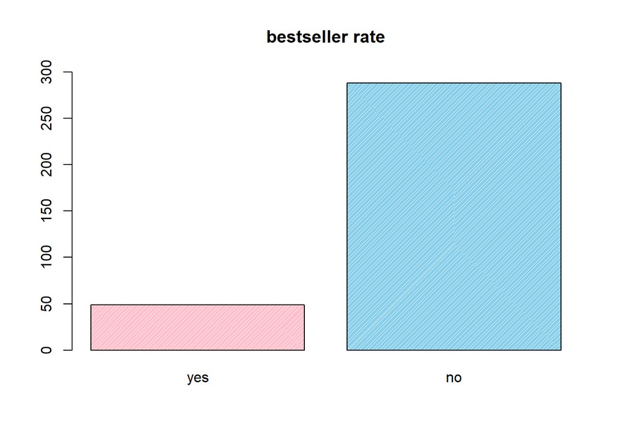

```r
x<-c(nrow(best[best$best_seller==1,]), nrow(best[best$best_seller==0,]))
names(x)<-c('yes','no')
barplot(x,col=c('pink','skyblue'),density=80, main="bestseller rate",ylim=c(0,300))
```

bsetseller의 컬럼 시각화입니다.

- price

price는 factor 형식의 데이터이고 영문과 특수문자가 섞여있어서 영문과 특수문자를을 제거한 후 as.numeric으로 숫자로 변환해주었습니다.

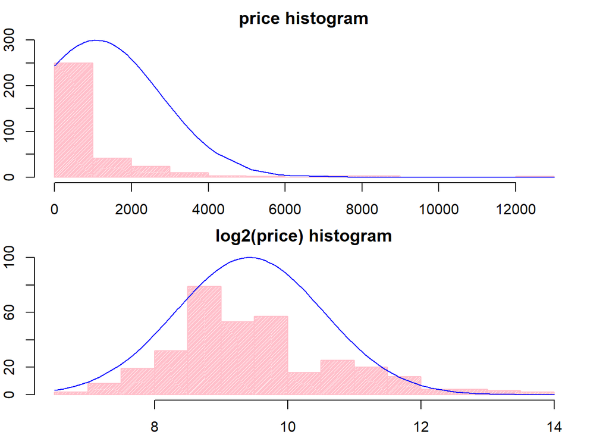

```r
best$price<-substr(best$price,3,100)
best$price<-gsub("[^[:alnum:][:blank:]+?&/\\-]", "", best$price)
best$price<-as.numeric(best$price)

prso<-sort(best$price)
par(mfrow=c(2,1))
par(mar=c(2,2,2,2))

hist(best$price,col='pink',density=80, main='price histogram',ylim=c(0,300))
par(new=T)
plot(prso, dnorm(prso,mean=mean(prso),sd=sd(prso)),type='l',axes=FALSE,ann=FALSE,col='blue')

hist(log2(as.integer(best$price)),col='pink',density=80, main='log2(price) histogram',ylim=c(0,100))
par(new=T)
plot(log2(prso), dnorm(log2(prso),mean=mean(log2(prso))),sd=sd(log2(prso)),type='l',axes=FALSE,ann=FALSE,col='blue')
```

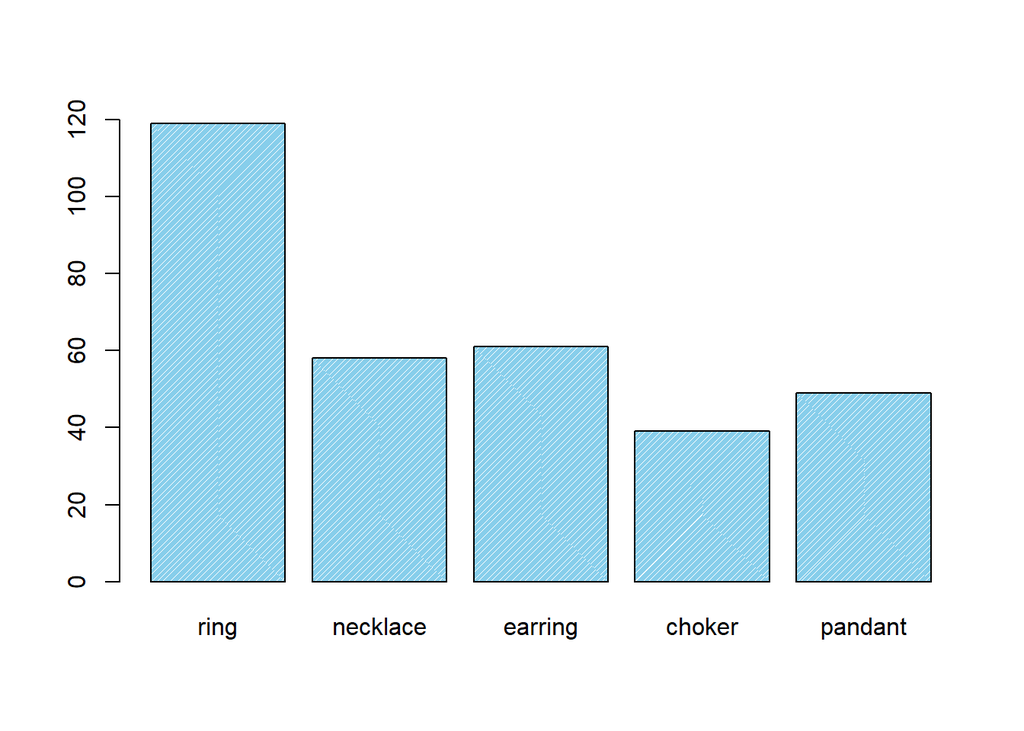

```r
ac<-c(nrow(best[best$ring==1,]),nrow(best[best$necklace==1,]),
      nrow(best[best$earring==1,]),nrow(best[best$choker==1,]),
      nrow(best[best$pendant==1,]))
names(ac)<-c('ring','necklace','earring','choker','pandant')
barplot(ac,col='skyblue',ylim=c(0,120),density=80)
```

- 악세사리에 포함된 보석의 개수

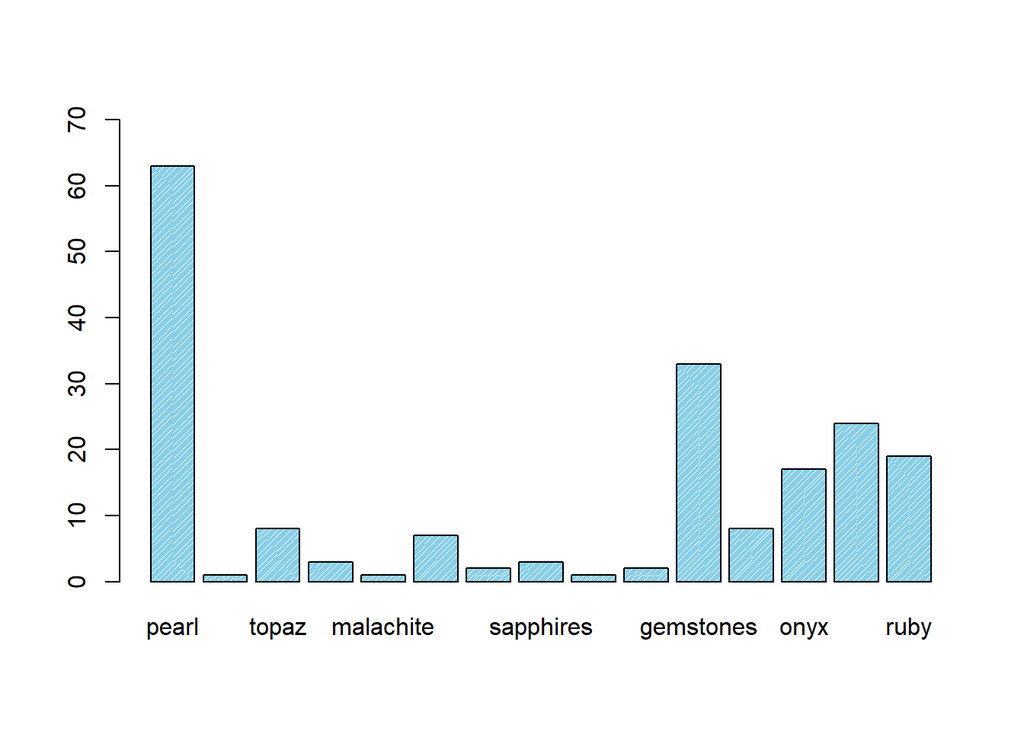

```r
ju<-c(nrow(best[best$pearl==1,]),nrow(best[best$opal==1,]),
      nrow(best[best$topaz==1,]),nrow(best[best$amethyst==1,]),
      nrow(best[best$malachite==1,]),nrow(best[best$amazonite==1,]),
      nrow(best[best$labradorite==1,]),nrow(best[best$sapphires==1,]),
      nrow(best[best$agate==1,]),nrow(best[best$quartzite==1,]),
      nrow(best[best$gemstones==1,]),nrow(best[best$spinel==1,]),
      nrow(best[best$onyx==1,]),nrow(best[best$diamonds==1,]),
      nrow(best[best$ruby==1,]))
names(ju)<-c('pearl','opal','topaz','amethyst','malachite','amazonite',
             'labradorite','sapphires','agate','quartzite','gemstones',
             'spinel','onyx','diamonds','ruby')
barplot(ju,col='skyblue',ylim=c(0,70),density=80)
```

## **데이터로 모델 훈련-의사결정트리**

```r
set.seed(0)
best_shuffle <- best[ sample( nrow(best) ),  ]
train_num<-round(0.8 * nrow(best_shuffle), 0)
best_train<-best_shuffle[1:train_num ,-1]
best_test<-best_shuffle[(train_num+1) : nrow(best_shuffle),-1 ]
best_model<-C5.0(best_train[ ,-1] ,best_train[  ,1] )
best_train[best_train[  ,1]=='none',]
best_model[]

best_pred <-predict(best_model,best_test )
```

- 모델 성능 평가

```r
CT<-CrossTable(best_test[ , 1],best_pred )
```

```
##
##
##    Cell Contents
## |-------------------------|
## |                       N |
## | Chi-square contribution |
## |           N / Row Total |
## |           N / Col Total |
## |         N / Table Total |
## |-------------------------|
##
##
## Total Observations in Table:  67
##
##
##                | best_pred
## best_test[, 1] |         0 |         1 | Row Total |
## ---------------|-----------|-----------|-----------|
##              0 |        54 |         2 |        56 |
##                |     0.034 |     0.540 |           |
##                |     0.964 |     0.036 |     0.836 |
##                |     0.857 |     0.500 |           |
##                |     0.806 |     0.030 |           |
## ---------------|-----------|-----------|-----------|
##              1 |         9 |         2 |        11 |
##                |     0.174 |     2.748 |           |
##                |     0.818 |     0.182 |     0.164 |
##                |     0.143 |     0.500 |           |
##                |     0.134 |     0.030 |           |
## ---------------|-----------|-----------|-----------|
##   Column Total |        63 |         4 |        67 |
##                |     0.940 |     0.060 |           |
## ---------------|-----------|-----------|-----------|
##
##
```

```r
print(paste('정확도 : ',(CT$prop.tbl[1]+CT$prop.tbl[4])*100))
```

```
## [1] "정확도 :  83.5820895522388"
```

bestseller를 예측하는 정확도가 약 83.58% 나왔습니다.

- 클래스 균형화 위의 yes와 no비율 그래프로 보면 yes와 no의 비율차이가 많이 납니다. 이러한 상태를 클래스 불균형 상태라고 하는데 이런 상태로 훈련을 시키면 비율이 높은 클래스만 훈련이 많이 되서 예측결과가 부정확하게 나올수 있습니다.따라서 훈련을 하기 전에 yes와 no가 비율차이를 줄여주겠습니다. 불균형을 줄여주는 방법에는 upSample, downSample, SMOTE 등 여러가지가 있지만 여기서는 SMOTE을 사용하겠습니다.

```r
best <- read.csv("c:\\data\\bestseller.csv")

best<-best[c(-4,-22,-23,-25,-26,-27,-29,-30)]

for(i in 1:ncol(best)){
  best[,i] <- factor(best[,i])  }

best$price<-substr(best$price,3,100)
best$price<-gsub("[^[:alnum:][:blank:]+?&/\\-]", "", best$price)
best$price<-as.numeric(best$price)
```

```r
best<-SMOTE(best_seller~.,best,perc.over=2000,perc.under=110)
table(best$best_seller)
```

```
##
##    0    1
## 1078 1029
```

```r
set.seed(0)
best_shuffle <- best[ sample( nrow(best) ),  ]
train_num<-round(0.8 * nrow(best_shuffle), 0)
best_train<-best_shuffle[1:train_num ,-1]
best_test<-best_shuffle[(train_num+1) : nrow(best_shuffle),-1 ]
best_model<-C5.0(best_train[ ,-1] ,best_train[  ,1] )
best_pred <-predict(best_model,best_test)
```

```r
CT<-CrossTable(best_test[ , 1],best_pred )
```

```
##
##
##    Cell Contents
## |-------------------------|
## |                       N |
## | Chi-square contribution |
## |           N / Row Total |
## |           N / Col Total |
## |         N / Table Total |
## |-------------------------|
##
##
## Total Observations in Table:  421
##
##
##                | best_pred
## best_test[, 1] |         0 |         1 | Row Total |
## ---------------|-----------|-----------|-----------|
##              0 |       210 |         9 |       219 |
##                |    51.712 |    73.408 |           |
##                |     0.959 |     0.041 |     0.520 |
##                |     0.850 |     0.052 |           |
##                |     0.499 |     0.021 |           |
## ---------------|-----------|-----------|-----------|
##              1 |        37 |       165 |       202 |
##                |    56.065 |    79.586 |           |
##                |     0.183 |     0.817 |     0.480 |
##                |     0.150 |     0.948 |           |
##                |     0.088 |     0.392 |           |
## ---------------|-----------|-----------|-----------|
##   Column Total |       247 |       174 |       421 |
##                |     0.587 |     0.413 |           |
## ---------------|-----------|-----------|-----------|
##
##
```

```r
print(paste('정확도 : ',(CT$prop.tbl[1]+CT$prop.tbl[4])*100))
```

```
## [1] "정확도 :  89.0736342042755"
```

클래스 불균형을 해결하기 전의 정확도는 약 83.58% 가 나왔습니다. 클래스 불균형을 줄여준 뒤의 정확도는 약 89.07%으로 정확도가 올랐습니다.

- Roc

예측 데이터 프레임을 생성합니다.

```r
best_test_prob <- predict(best_model,best_test,type="prob")
best_results2 <- data.frame(actual_type=best_test[  , 1],
                            predict_type=best_pred,
                            prob_edible=round(best_test_prob[ ,1], 5),
                            prob_poisonous=round(best_test_prob[ ,2], 5) )
```

예측 데이터 프레임을 csv로 저장합니다.

```r
write.csv(best_results2, "c:\\data\\best_results_c50.csv", row.names = FALSE)
```

ROC 커브를 그립니다.

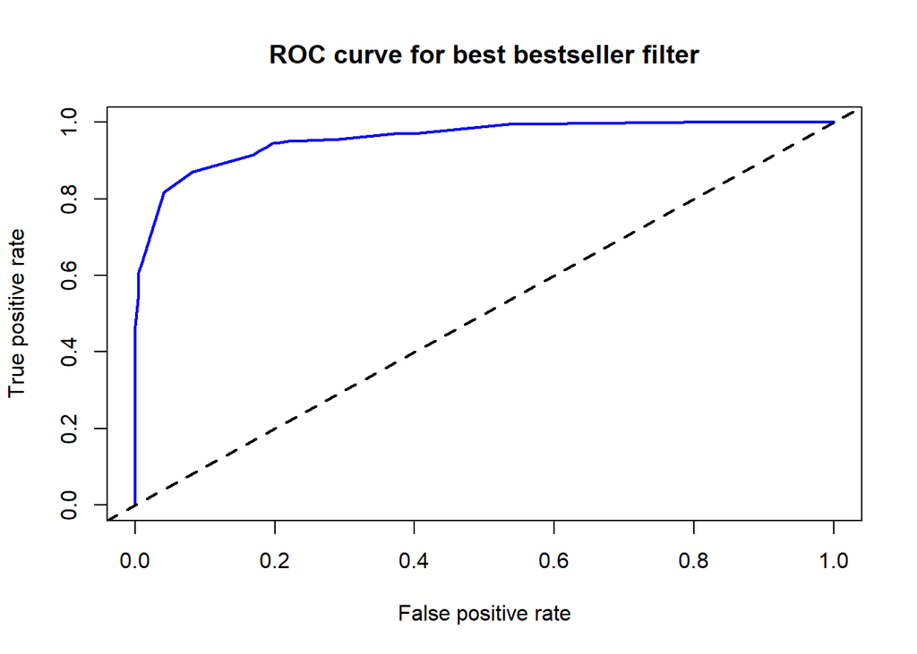

AUC 값을 출력합니다.

```r
perf.auc <- performance(pred, measure = "auc")
unlist(perf.auc@y.values)
```

```
## [1] 0.9582938
```

AUC값은 약 0.96가 나왔습니다.

- 모델 성능 개선

의사결정트리에서 정확도를 높이는 방법은 trials값을 높이는 것입니다. 가장 적절한 trials값을 찾는 것을 시각화 하겠습니다.

```r
a2<-c()
for (i in 1:100){
  if(!i %in% c(3,4) ){
    best_model<-C5.0( best_train[ ,-1] , best_train[ , 1],trials=i)
    best_result<-predict( best_model, best_test[ , -1] )
    a<-CrossTable( best_test[, 1], best_result )
    a2<-append(a2,(a$prop.tbl[1]+a$prop.tbl[4])) } }
```

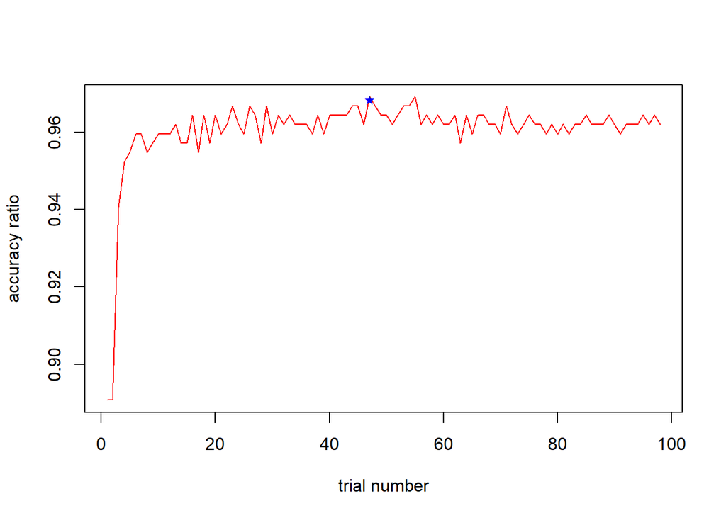

```r
a3<-data.table('idx'=c(1:98),'pred'=a2)
plot(a3,type='l',col='red',xlim=c(1,98), ylim=c(min(a3$pred),max(a3$pred)),ann=F,axes=FALSE)
par(new=T)
plot(which.max(a3$pred),max(a3$pred),xlim=c(1,98),
     ylim=c(min(a3$pred),max(a3$pred)),type='o', col='blue',
     pch='★',xlab='trial number', ylab='accuracy ratio')
```

```r
print(paste('가장 적절한 trials 값 : ',min(a3[a3$pred==max(a3$pred),'idx'])))
```

```
## [1] "가장 적절한 trials 값 :  47"
```

```r
best_model<-C5.0(best_train[ ,-1] ,best_train[  ,1],trials=47 )
best_pred <-predict(best_model,best_test)
CT2<-CrossTable(best_test[   , 1],best_pred )
```

```
##
##
##    Cell Contents
## |-------------------------|
## |                       N |
## | Chi-square contribution |
## |           N / Row Total |
## |           N / Col Total |
## |         N / Table Total |
## |-------------------------|
##
##
## Total Observations in Table:  421
##
##
##                | best_pred
## best_test[, 1] |         0 |         1 | Row Total |
## ---------------|-----------|-----------|-----------|
##              0 |       216 |         3 |       219 |
##                |    81.195 |    95.006 |           |
##                |     0.986 |     0.014 |     0.520 |
##                |     0.952 |     0.015 |           |
##                |     0.513 |     0.007 |           |
## ---------------|-----------|-----------|-----------|
##              1 |        11 |       191 |       202 |
##                |    88.028 |   103.002 |           |
##                |     0.054 |     0.946 |     0.480 |
##                |     0.048 |     0.985 |           |
##                |     0.026 |     0.454 |           |
## ---------------|-----------|-----------|-----------|
##   Column Total |       227 |       194 |       421 |
##                |     0.539 |     0.461 |           |
## ---------------|-----------|-----------|-----------|
##
##
```

```r
print(paste('정확도 : ',(CT2$prop.tbl[1]+CT2$prop.tbl[4])*100))
```

```
## [1] "정확도 :  96.6745843230404"
```

정확도가 83.58%에서 96.67%로 올랐습니다.

- 민감도

```r
for(i in 1:ncol(best_results)){
  best_results[,i] <- factor(best_results[,i])  }
sensitivity(best_results$predict_type, best_results$actual_type,positive='1')
```

```
## [1] 0.8168317
```

- 특이도

```r
specificity(best_results$predict_type, best_results$actual_type,negative='0')
```

```
## [1] 0.9589041
```

특이도는 0.95가 나왔습니다. 특이도는 실제 거짓인 것 중에서 거짓으로 예측한 비율로 위의 데이터에서는 bestseller가 아닌 물건중에 bestseller가 아니라고 예측된 물건의 비율입니다.특이도 또한 0에서 1까지의 범위에 있으면 값이 1에 가까울수록 바람직한데 0.95으로 높은 수치의 민감도가 나왔습니다.

## **데이터로 모델 훈련-나이브베이즈**

```r
best <- read.csv("c:\\data\\bestseller.csv")

best<-best[c(-4,-22,-23,-25,-26,-27,-29,-30)]

best$price<-substr(best$price,3,100)
best$price<-gsub("[^[:alnum:][:blank:]+?&/\\-]", "", best$price)
best$price<-as.numeric(best$price)

for(i in 1:ncol(best)){
  best[,i] <- factor(best[,i])  }
```

```r
best<-SMOTE(best_seller~.,best,perc.over=2000,perc.under=110)
table(best$best_seller)
```

```
##
##    0    1
## 1078 1029
```

```r
set.seed(0)
best_shuffle <- best[ sample( nrow(best) ),  ]
train_num<-round(0.8 * nrow(best_shuffle), 0)
best_train<-best_shuffle[1:train_num ,-1]
best_test<-best_shuffle[(train_num+1) : nrow(best_shuffle),-1 ]
best_model<-naiveBayes(best_seller~.,data=best_train)
best_pred<-predict(best_model, best_test[ , -1] )
```

```r
CT<-CrossTable(best_test[ , 1],best_pred )
```

```
##
##
##    Cell Contents
## |-------------------------|
## |                       N |
## | Chi-square contribution |
## |           N / Row Total |
## |           N / Col Total |
## |         N / Table Total |
## |-------------------------|
##
##
## Total Observations in Table:  421
##
##
##                | best_pred
## best_test[, 1] |         0 |         1 | Row Total |
## ---------------|-----------|-----------|-----------|
##              0 |       187 |        32 |       219 |
##                |    67.324 |    60.349 |           |
##                |     0.854 |     0.146 |     0.520 |
##                |     0.940 |     0.144 |           |
##                |     0.444 |     0.076 |           |
## ---------------|-----------|-----------|-----------|
##              1 |        12 |       190 |       202 |
##                |    72.990 |    65.428 |           |
##                |     0.059 |     0.941 |     0.480 |
##                |     0.060 |     0.856 |           |
##                |     0.029 |     0.451 |           |
## ---------------|-----------|-----------|-----------|
##   Column Total |       199 |       222 |       421 |
##                |     0.473 |     0.527 |           |
## ---------------|-----------|-----------|-----------|
##
##
```

```r
print(paste('정확도 : ',(CT$prop.tbl[1]+CT$prop.tbl[4])*100))
```

```
## [1] "정확도 :  89.5486935866983"
```

- 예측 데이터 프레임 csv로 저장

```r
best_test_prob<-predict(best_model,best_test,type="raw")
best_results2<-data.frame(actual_type=best_test[,1],
                          predict_type=best_pred,
                          prob_nonbestseller=round(best_test_prob[ ,1], 5),
                          prob_bestseller=round(best_test_prob[ ,2], 5) )
write.csv(best_results2, "c:\\data\\best_results_na.csv", row.names = FALSE)
```

- 모델 성능 개선

```r
n<-seq(0.1,1,by=0.01)
a2=c( )
for (i in n){
  best_model2 <- naiveBayes(best_seller~ . , data=best_train, laplace=i)
  best_pred2 <- predict( best_model2, best_test[ , -1] )
  a<-CrossTable( best_test[ ,1], best_pred2)
  a2<-append(a2,(a$prop.tbl[1]+a$prop.tbl[4])) }
```

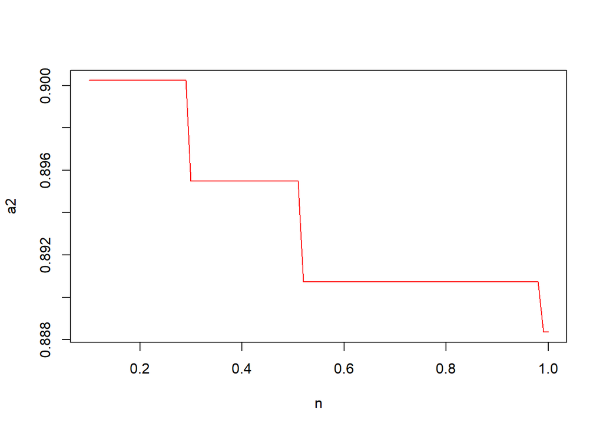

```r
plot(n,a2,type='l',col='red')
```

```r
best_model2 <- naiveBayes(best_seller~ . , data=best_train, laplace=0.04)
best_pred2 <- predict( best_model2, best_test[ , -1] )
CT2<-CrossTable( best_test[ ,1], best_pred2)
```

```
##
##
##    Cell Contents
## |-------------------------|
## |                       N |
## | Chi-square contribution |
## |           N / Row Total |
## |           N / Col Total |
## |         N / Table Total |
## |-------------------------|
##
##
## Total Observations in Table:  421
##
##
##                | best_pred2
## best_test[, 1] |         0 |         1 | Row Total |
## ---------------|-----------|-----------|-----------|
##              0 |       189 |        30 |       219 |
##                |    68.196 |    62.306 |           |
##                |     0.863 |     0.137 |     0.520 |
##                |     0.940 |     0.136 |           |
##                |     0.449 |     0.071 |           |
## ---------------|-----------|-----------|-----------|
##              1 |        12 |       190 |       202 |
##                |    73.935 |    67.550 |           |
##                |     0.059 |     0.941 |     0.480 |
##                |     0.060 |     0.864 |           |
##                |     0.029 |     0.451 |           |
## ---------------|-----------|-----------|-----------|
##   Column Total |       201 |       220 |       421 |
##                |     0.477 |     0.523 |           |
## ---------------|-----------|-----------|-----------|
##
##
```

```r
print(paste('정확도 : ',(CT2$prop.tbl[1]+CT2$prop.tbl[4])*100))
```

```
## [1] "정확도 :  90.0237529691211"
```

```r
best_results<-read.csv('c:\\data\\best_results_na.csv')
for(i in 1:ncol(best_results)){
  best_results[,i] <- factor(best_results[,i])  }
```

- 민감도

```r
sensitivity(best_results$predict_type, best_results$actual_type,positive='1')
```

```
## [1] 0.9405941
```

- 특이도

```r
specificity(best_results$predict_type, best_results$actual_type,negative='0')
```

```
## [1] 0.8538813
```